# Local associations: second null model

This notebook follows on from Local groups.nb.Rmd, in which I attempted to adduce evidence for local pairwise co-occurence between plant taxa in the River Ouse Project meadows database. I am greatly indebted to Aaron Ellison for drawing my attntion to the general topic of null models, and in particular to Nick Gotelli & Gary Graves’ Null Models in Ecology: [link](https://www.uvm.edu/~ngotelli/nullmodelspage.html). The epilogue to that book contains this advice:

*We suggest that ecologists ask themselves the following questions before submitting the results of a null model study for publication:*

*1. Were the species data (measurements, geographic distributions, habitat, etc.) of high quality and derived from personal field work, specimens, or original literature sources?*

*2. Were source pools constructed with a standardized methodology, taking into account the spatial distribution of habitats and resources?*

*3. Was the null model used appropriate for the question at hand, and was it thoroughly described in the methods so that others could use it?*

*4. Was the computer implementation of the null model checked for programming errors and was it tested with idealized data sets?*

*5. Were the ceteris paribus assumptions defended and discussed?*

*6. Will source pool and island species data be published or deposlted in a databank for public access?*

Here, I’m concentrating on item 3 because I hadn’t thought hard enough about the null model and now think it was probably inadequate. What follows is an attempt at a better null model which I am pretty sure will vastly reduce, and possibly eliminate entirely, all my previously supposed evidence for local pairwise association.

My previous model successfully preserved stand-level associations while randomising out any possible local associations within the 5 quadrats of a stand. But it did that without preserving the species composition of a stand. The real data were compared with an entirely simulated set composed of abstract “stands” constructed purely from the data-wide marginal probabilities and odds-ratio of each species pair. In effect, I was asking “if this pair occurred in a stand with frequencies governed by their data-wide contingency table, what would be the expected quadrat odds ratio given no extra local association?” This approach treats all stands as equivalent, which is not realistic as we know that several different kinds of mesotrophic grassland were included in the survey, and the result is not directly comparable with the original data.

The approach to be attempted here is to modify the original data set by randomising the assignment of a stand’s species to the quadrats, thus destroying any local associations that might be present while retaining both the stand-level association (odds ratio for each pair) and the species composition of the stand.

The following code loads libraries, functions, gets the stand- and quadrat- odds ratios, and plots quadrat-odds ratios vs stand-odds ratios for each species pair.

We have 67 species, 2211 pairs.

Restricting the analysis to pairs with more than 20 co-occurences reduces the number of pairs to 699.

## Stand- and quadrat- level contingencies.

The contingency tables could be constructed with co-occurences in stands (5 quadrats) or in individual quadrats. The chance of finding two species together in a five quadrat stand is clearly greater than finding them together in a single quadrat. The regression of quadrat odds ratio on stand odds ratio (Figure 1) is 0.68, less than 1.0, as expected.

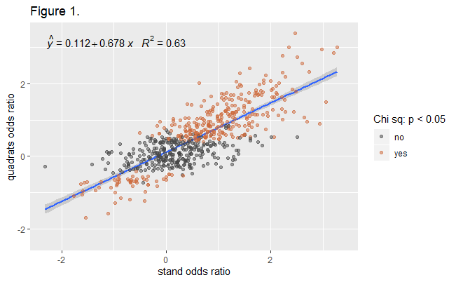

```r
  lin_model <- y ~ x # For stat_poly_eq
# Plot quadrat OR vs assembly OR. Note slope < 1.0; assemblies OR
# tend to be higher than quadrat OR because of increased expectation that
# a pair of plants will be found together in the larger area.
plt1 <- ggplot(pwor, aes(x=aor, y=qor)) +
  geom_smooth(method = lm) +
  stat_poly_eq(formula = lin_model,
               eq.with.lhs = "italic(hat(y))~`=`~",
               aes(label = paste(..eq.label.., ..rr.label.., sep = "~~~")),
               parse = TRUE) +
  geom_point(aes(colour = sfx), alpha = 0.5) +
  scale_colour_manual(values = c("grey27", "sienna3"), name = "Chi sq: p < 0.05") +
  labs(x = "stand odds ratio", y = "quadrats odds ratio") +
  ggtitle("Figure 1.") +
  theme_grey() + coord_cartesian(xlim = c(min(pwor$aor), max(pwor$qor)),
                                 ylim = c(min(pwor$aor), max(pwor$qor)))
plot(plt1)
```

The scatter of points around the regression line in Figure 1 suggested that for some species pairs there might be a greater than expected chance of finding them in the same quadrat, while for othere there might be less, perhaps indicating some short range (on the scale of 2m x 2m) interactions.

## Are the quadrat-level associations stronger than might be expected?

Uniform stands are never truly uniform but have some level of granularity within which variations in abiotic or biotic environmental factors play a part in determining which species are locally present. It seemed worthwhile to examine whether the quadrat level associations may be stronger than would be expected by chance from the observed stand level associations.

Here I make a modified data set, d2, in which assignment of species to quadrats *within each stand* is randomised, eliminating any local association, but preserving the overall species composition of the stand.

We want to repeat the quadrat level analysis on d2, and eventually to keep the same set of species pairs that were used to make Figure 1. Figures 2a and b are the outcome of this analysis.

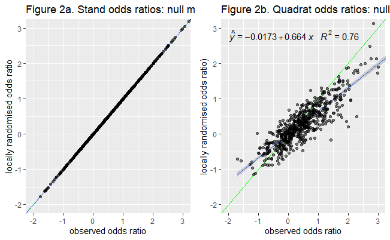

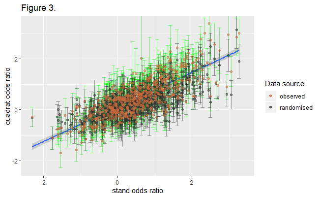

The confidence intervals in Figure 3 are 1.95(standard error) using the approximation

$SE = \sqrt{\frac{1}{n_{11}}+\frac{1}{n_{10}}+\frac{1}{n_{01}}+\frac{1}{n_{00}}}$

## Which species pairs exhibit local association?

Pairs for which the lower limit of the observed quadrat confidence interval is above the upper limit of the null model confidence interval are taken as showing a significant local association (Table 1).

|  | A | B | log(odds ratio) | shared quadrats |
| --- | --- | --- | --- | --- |
| 1 | Anthoxanthum_odoratum | Brachythecium_rutabulum | 1.07400525954306 | 150 |
| 2 | Anthoxanthum_odoratum | Centaurea_nigra | 1.94303599392545 | 133 |
| 3 | Anthoxanthum_odoratum | Lotus_corniculatus | 1.73837449540709 | 226 |
| 4 | Anthoxanthum_odoratum | Luzula_campestris | 1.79332319120424 | 120 |
| 5 | Anthoxanthum_odoratum | Ranunculus_acris | 1.14676914059345 | 287 |
| 6 | Centaurea_nigra | Festuca_rubra | 1.52795477389857 | 98 |
| 7 | Cerastium_fontanum | Trifolium_repens | 1.5001995441223 | 213 |
| 8 | Dactylis_glomerata | Lathyrus_pratensis | 1.36832966643185 | 67 |
| 9 | Hypochaeris_radicata | Leucanthemum_vulgare | 2.99345695971686 | 40 |
| 10 | Hypochaeris_radicata | Plantago_lanceolata | 3.38900920920207 | 62 |

[output cut: 6 more lines]

|  | A | B | log(odds ratio) | shared quadrats |
| --- | --- | --- | --- | --- |
| 1 | Anthoxanthum_odoratum | Poa_trivialis | -1.04908925528302 | 156 |

This analysis strongly that several plant pairs in mesotrophic grassland samples tend to be locally associated. As expected, the number of local associations that can be positively identified is less than in the previous (probably flawed) attempt, but not negligible. It is likely that some local associations have been excluded due to type II errors (false negative); rejection of the alternative hypothesis does not imply acceptance of the null.

Further notebooks will examine other techniques for detecting local assocation, and explore the relationships between locally associated taxa. While probably not in notebook form, I will attend to the other recommendations made by Gotelli and Graves!